# Actividad 2: Modelos de Regresión Espacial

Korina Yeizel Medellín Bañuelos-A01540325 | Ángel Iván Cadena Altamirano-A01706689 | Mauricio García Garza-A01177347 | José Xavier Higuera Alanis-A01204670 | Keyla Patricia Islas Garrido-A01730349

2023-05-02

AD3003B – Planeación Estartégica Basada en Analítica Prescriptiva  
Módulo 1 – Modelos Analíticos Avanzados para la Inteligencia de Negocios  
Feb – Jun 2023

## Introducción a la Situación Problema

De acuerdo a la Cámara Nacional de la Industria Farmacéutica, (CANIFARMA) en México las personas en situación de pobreza se caracterizan por tener una probabilidad 5 veces mayor de fallecer por COVID-19 que las personas con relativamente mayor nivel de ingresos (Arceo- Gómez, et al., 2021)2. Además de la falta de acceso a servicios de salud y posibles cormobilidades, otro factor relevante en incrementar dicha probabililidad es el perfil socioeconómico (Arceo-Gómez, et al., 2021).

A partir de la pandemia por COVI19, la firma de consultoría XYZ (México) establece que “Las organizaciones que su principal actividad de negocios es brindar servicios de salud requiren soluciones específicas e innovadoras, para aprovechar oportunidades, afrontar retos, así como favorecer su consolidación y crecimiento”. Algunos de los servicios enfocados por parte de la firma es detectar las necesidades y potencial del crecimiento del sector salud a partir de Analítica de Datos.

## Objetivo

Mediante la estimación de diferentes modelos de regresión predeciremos los factores asociados con el incremento / disminción de casos confirmados de COVID-19 a nivel municipal para el caso de México durante el periodo 2020 – 2021.

## Location Intelligence y ESDA

Brevemente, describir cómo el análisis espacial de datos se relaciona con la herramienta de inteligencia de negocios “Location Intelligence”

El análisis espacial de datos ayuda a entender el comportamiento de una o más variables en un lugar. La herramienta de Location Intelligence ayuda a mapear el comportamiento de una o más variables y estas se relacionan de manera que permiten obtener insights de las mismas variables en diferentes ubicaciones para contribuir a una mejor toma de decisiones y generacion de objetivos coherentes.

## Regresión no espacial

```r
str(global)
```

```
## 'data.frame':    2457 obs. of  46 variables:
##  $ X                             : int  1 2 3 4 5 6 7 8 9 10 ...
##  $ cve_ent                       : int  1001 1002 1003 1004 1005 1006 1007 1008 1009 1010 ...
##  $ mpio                          : chr  "Aguascalientes" "Asientos" "Calvillo" "Cosio" ...
##  $ poblacion_2022                : int  961977 50864 60760 16918 130184 50032 57981 9661 22743 21947 ...
##  $ hogrem2015                    : chr  "4.819" "12.867" "25.85" "14.294" ...
##  $ hogremjefmuj2015              : chr  "27.827" "22.054" "25.596" "21.171" ...
##  $ popnoafmed2015                : chr  "14.337" "5.774" "9.974" "5.283" ...
##  $ gini2015                      : chr  "0.392" "0.37" "0.375" "0.37" ...
##  $ popden2020                    : chr  "811.991" "94.087" "62.549" "131.885" ...
##  $ crimen_2018                   : num  7.36 7.81 8.4 17.86 5.14 ...
##  $ crimen_2019                   : num  8.15 5.78 8.31 0 10.98 ...
##  $ inclusion_fin_2019            : num  1.78 0 1.16 0 0.36 1.2 1.03 0 0 0 ...
##  $ porcentaje_pob_pobreza        : num  23.7 40.1 45.8 37 26.3 ...
##  $ porcentaje_pob_pobreza_ext    : num  1.97 4.14 4.5 3.38 3.29 2.88 5.56 2.32 3.15 4.81 ...
```

[output cut: 32 more lines]

Ahora para homogeneizar las variables las convertimos a numericas y sea mejor el análisis.

```r
# Se normalizaron variables a numéricas
global$hogrem2015 <- as.numeric(global$hogrem2015)
global$hogremjefmuj2015 <- as.numeric(global$hogremjefmuj2015)
global$popnoafmed2015 <- as.numeric(global$popnoafmed2015)
global$gini2015 <- as.numeric(global$gini2015)
global$popden2020 <- as.numeric(global$popden2020)
```

A continuación veremos si existen NAs.

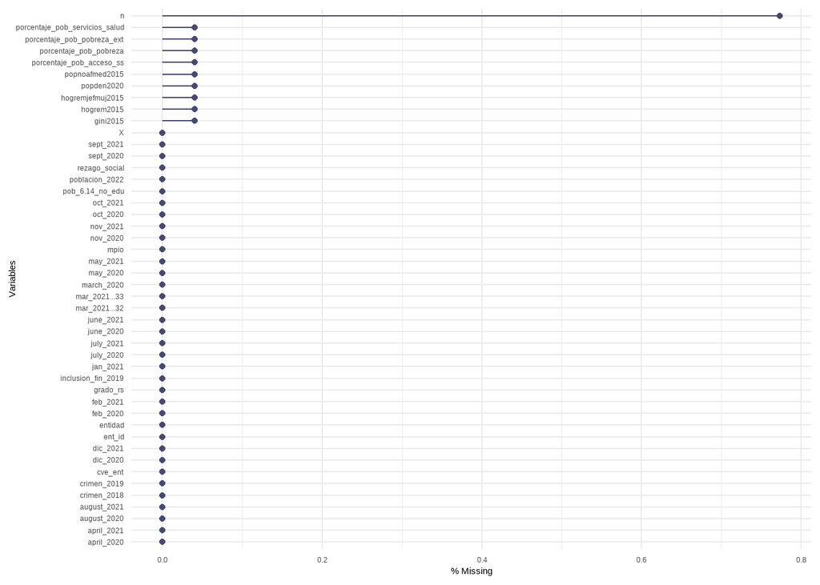

```r
#Visualizamos los NAs actuales
gg_miss_var(global, show_pct=TRUE)
```

En la gráfica anterior se visualiza que la variable n es la que más NAs contiene.

Ahora eliminamos los NA al reemplazar los valores.

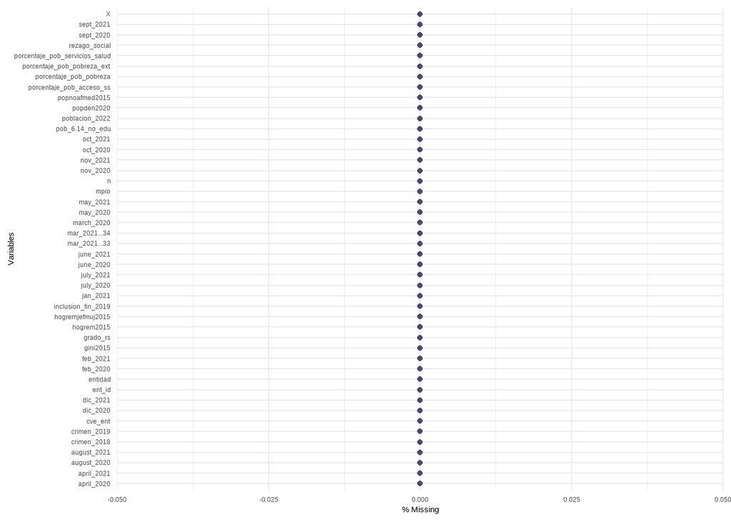

```r
#Realizamos el método de Predictive Mean Matching de la librería Mice para eliminar nuestros NAs.
global_clean <- mice(global, method = "pmm")
table(is.na(global_clean))
global_clean <- complete(global_clean)
gg_miss_var(global_clean, show_pct=TRUE)
```

Ahora pasamos a limpiar la base de datos

```r
df <- global_clean[,c(2:19,44:46)]
df["covid2021"] <- rowSums(global_clean[,c(31,32,34:43)])
df <- df[-1813,]
df$hogremjefmuj2015[df$hogremjefmuj2015 ==0] <- 0.01
df$porcentaje_pob_pobreza_ext[df$porcentaje_pob_pobreza_ext ==0] <- 0.01
df$covid2021[df$covid2021 ==0] <- 0.01
```

Una vez configurada la base de datos, la particionamos para hacer un conjunto de datos para entrenamiento y pruebas.

```r
set.seed(123)
partition <- createDataPartition(y = df$covid2021, p=0.75, list=F)
train = df[partition, ]
test <- df[-partition, ]
```

```r
mx_mpios <- readOGR(dsn = "spda_covid19/shp_mx_mpios/mx_mpios.shp") ### geospatial data.
mx_geodata<-geo_join(mx_mpios,df,'IDUNICO','cve_ent',how='inner') ### Combining geospatial and non-spatial data
```

Se crea una lista de vecinos en la variable swm_queen.

```r
swm_queen <- poly2nb(mx_mpios, queen = TRUE)
summary(swm_queen)
```

```
## Neighbour list object:
## Number of regions: 2456
## Number of nonzero links: 14392
## Percentage nonzero weights: 0.2385967
## Average number of links: 5.859935
## Link number distribution:
##
##   1   2   3   4   5   6   7   8   9  10  11  12  13  14  15  16  17  19  20  22
##   8  63 202 393 515 467 317 233 143  52  27  15   5   4   3   3   1   1   1   3
## 8 least connected regions:
## 299 354 667 858 930 1243 1461 2234 with 1 link
## 3 most connected regions:
## 966 1058 1173 with 22 links
```

Ahora para concluir con el método no espacial en rswm_queen le complementamos a la lista de vecinos un peso espacial.

```r
rswm_queen <- nb2listw(swm_queen, style = "W", zero.policy = TRUE)
rswm_queen
```

```
## Characteristics of weights list object:
## Neighbour list object:
## Number of regions: 2456
## Number of nonzero links: 14392
## Percentage nonzero weights: 0.2385967
## Average number of links: 5.859935
##
## Weights style: W
## Weights constants summary:
##      n      nn   S0       S1       S2
## W 2456 6031936 2456 898.7549 10338.48
```

## Modelo de Regresión con ML (Random Forest)

```r
random_forest<-randomForest(covid2021~.,data=train,importance=TRUE, proximity=TRUE)
print(random_forest) ### the train data set model accuracy is around 73%.
```

```
##
## Call:
##  randomForest(formula = covid2021 ~ ., data = train, importance = TRUE,      proximity = TRUE)
##                Type of random forest: regression
##                      Number of trees: 500
## No. of variables tried at each split: 7
##
##           Mean of squared residuals: 5550329
##                     % Var explained: 74.21
```

```r
rf_prediction_test_data <-predict(random_forest,test)
rmse(rf_prediction_test_data, test$covid2021)
```

```
## [1] 4268.285
```

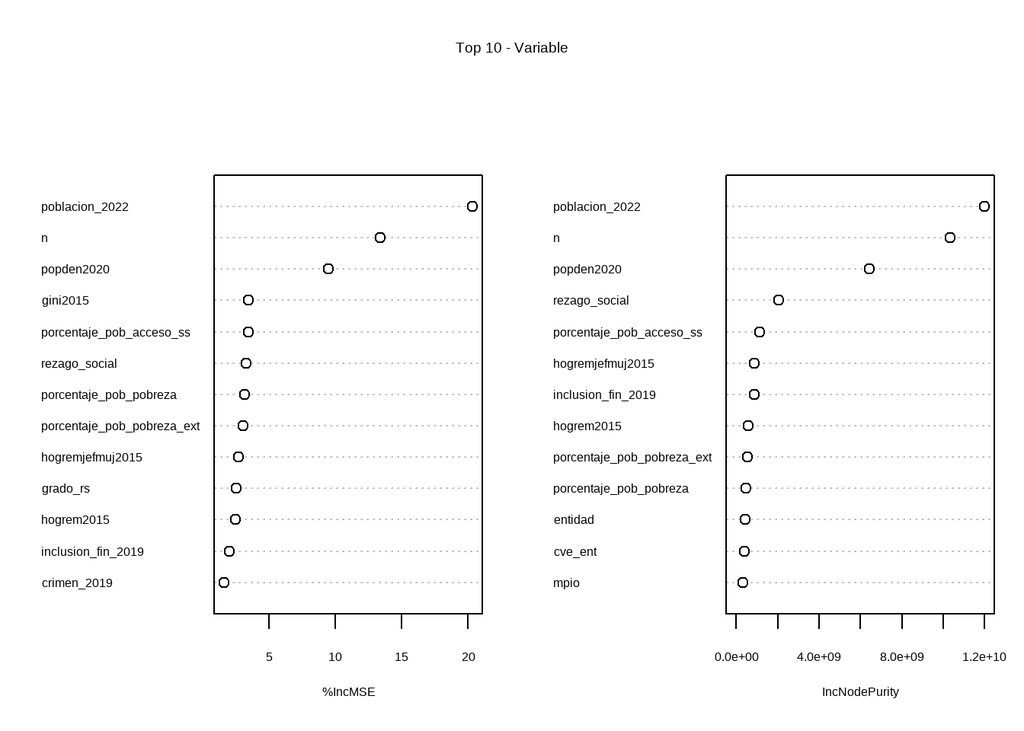

```r
varImpPlot(random_forest, n.var = 13, main = "Top 10 - Variable")
```

```r
importance(random_forest)
```

```
##                                   %IncMSE IncNodePurity
## cve_ent                        -1.2928436     402491292
## mpio                           -0.4053037     331353246
## poblacion_2022                 20.3326553   11992699607
## hogrem2015                      2.4517098     566393001
## hogremjefmuj2015                2.7067931     868795520
## popnoafmed2015                 -1.2049031     208201806
## gini2015                        3.4631031     165813034
## popden2020                      9.4826124    6436143138
## crimen_2018                    -1.0671708     221230684
## crimen_2019                     1.6191008     194168250
## inclusion_fin_2019              2.0291569     859723288
## porcentaje_pob_pobreza          3.1365127     455658089
## porcentaje_pob_pobreza_ext      3.0627581     555406149
## porcentaje_pob_servicios_salud  0.6083834     198820996
## porcentaje_pob_acceso_ss        3.4297625    1142583812
## pob_6.14_no_edu                -0.7699254     299920762
## rezago_social                   3.2522104    2050363115
## grado_rs                        2.5023124      73920779
## ent_id                          1.1966028     206481516
## n                              13.3944865   10317387347
## entidad                         0.7103045     444182818
```

## Justificación de la regresión espacial por el ESDA

El análisis de regresión espacial que haremos a continuación se justifica ya que el ESDA (Análisis Exploratorio de Datos Espaciales) que realizamos en la actividad 1, por medio del global y local Moran, indica que existe una autocorrelación espacial en los datos. La autocorrelación espacial se refiere a la tendencia de los valores similares a agruparse en el espacio geográfico. Como los datos la presentaron, al usar el análisis de regresión espacial es una técnica de análisis que toma en cuenta esta autocorrelación.

En la actividad 1, observamos agrupaciones del estilo High-High en el caso de los municipios de la Ciudad de México para el ejemplo de casos de Covid, esto significando que si un municipio de la Ciudad de México tiene altos niveles de casos de Covid, sus municipios contiguos mostratrían altos niveles de covid.

Al tener presencia de autocorrelación espacial significativa, se justifica el uso de la regresión espacial, misma que puede proporcionar información adicional sobre los factores que influyen en los patrones espaciales de los datos.

Si el ESDA no hubiera indicado autocorrelación espacial significativa, entonces no se justifica el uso de técnicas de análisis espacial, y una regresión lineal simple podría ser suficiente para modelar los datos. Es decir, nuestro trabajo hubiera sido suficiente corriendo solo el random forest anterior.

## Regresión No Espacial

### Modelo de Regresión No Espacial

```r
### SPATIAL REGRESSION ANALYSIS
lm_model_alt <- lm(log(covid2021) ~ log(popden2020) + log(n) + log(porcentaje_pob_acceso_ss) + hogremjefmuj2015 + porcentaje_pob_pobreza_ext + exp(rezago_social), data = mx_geodata)
summary(lm_model_alt)
```

```
##
## Call:
## lm(formula = log(covid2021) ~ log(popden2020) + log(n) + log(porcentaje_pob_acceso_ss) +
##     hogremjefmuj2015 + porcentaje_pob_pobreza_ext + exp(rezago_social),
##     data = mx_geodata)
##
## Residuals:
##     Min      1Q  Median      3Q     Max
## -7.4559 -0.5846  0.0701  0.8025  3.6549
##
## Coefficients:
##                                Estimate Std. Error t value Pr(>|t|)
## (Intercept)                    5.463932   0.626660   8.719  < 2e-16 ***
## log(popden2020)                0.063218   0.020605   3.068  0.00218 **
## log(n)                         0.997371   0.022391  44.543  < 2e-16 ***
## log(porcentaje_pob_acceso_ss) -0.806831   0.143512  -5.622 2.10e-08 ***
## hogremjefmuj2015              -0.004369   0.004840  -0.903  0.36672
## porcentaje_pob_pobreza_ext    -0.027715   0.002413 -11.487  < 2e-16 ***
## exp(rezago_social)             0.006824   0.001460   4.674 3.12e-06 ***
## ---
## Signif. codes:  0 '***' 0.001 '**' 0.01 '*' 0.05 '.' 0.1 ' ' 1
##
## Residual standard error: 1.405 on 2449 degrees of freedom
## Multiple R-squared:  0.7027, Adjusted R-squared:  0.702
## F-statistic: 964.8 on 6 and 2449 DF,  p-value: < 2.2e-16
```

```r
lm.morantest(lm_model_alt, nb2listw(swm_queen)) # Moran's I statistic suggest spatial patterns in our dataset.
```

```
##
##  Global Moran I for regression residuals
##
## data:
## model: lm(formula = log(covid2021) ~ log(popden2020) + log(n) +
## log(porcentaje_pob_acceso_ss) + hogremjefmuj2015 +
## porcentaje_pob_pobreza_ext + exp(rezago_social), data = mx_geodata)
## weights: nb2listw(swm_queen)
##
## Moran I statistic standard deviate = 23.171, p-value < 2.2e-16
## alternative hypothesis: greater
## sample estimates:
## Observed Moran I      Expectation         Variance
##     0.2802119307    -0.0015113894     0.0001478252
```

En el modelo anterior no espacial se utilizó un modelo lineal en el que se estableció como variable dependiente el logaritmo de Covid2021 mientras que como variables explicativas se definieron log popden2020, log N, log porcentaje_pob_acceso_ss, hogremjefmuj2015, porcentaje_pob_pobreza_ext y exp rezago social.

Dicho esto el modelo resultó tener las variables de popden2020, n, porcentaje_pop_acceso_ss, porcentaje_pobreza_ext y rezago social como variables estadísticamente significativas en el comportamiento de la dependiente la cual es Covid 2021.

```r
# RMSE
sqrt(mean((mx_geodata$covid2021 - lm_model_alt$fitted.values)^2))
```

```
## [1] 5205.214
```

Ahora al hacer un teste de RMSE se obtuvo un valor de 5205.212 el cual es mayor al del modelo que se realizó de Random Forest.

## Regresiones Espaciales

### Modelo de Autoregresión Espacial

```r
### SPATIAL AUTOGRESSIVE MODEL
spatial_lag_model <- lagsarlm(log(covid2021) ~ log(popden2020) + log(n) + log(porcentaje_pob_acceso_ss) + hogremjefmuj2015 + porcentaje_pob_pobreza_ext + exp(rezago_social), data=mx_geodata, rswm_queen, method="Matrix", zero.policy = TRUE)
summary(spatial_lag_model)
```

```
##
## Call:lagsarlm(formula = log(covid2021) ~ log(popden2020) + log(n) +
##     log(porcentaje_pob_acceso_ss) + hogremjefmuj2015 + porcentaje_pob_pobreza_ext +
##     exp(rezago_social), data = mx_geodata, listw = rswm_queen,
##     method = "Matrix", zero.policy = TRUE)
##
## Residuals:
##       Min        1Q    Median        3Q       Max
## -7.223289 -0.496578  0.099984  0.733361  4.388971
##
## Type: lag
## Coefficients: (numerical Hessian approximate standard errors)
##                                 Estimate Std. Error z value  Pr(>|z|)
## (Intercept)                    3.6066745  0.5825838  6.1908 5.985e-10
## log(popden2020)                0.0103603  0.0290538  0.3566  0.721400
## log(n)                         0.8449499  0.0244344 34.5804 < 2.2e-16
## log(porcentaje_pob_acceso_ss) -0.7424424  0.1316735 -5.6385 1.715e-08
## hogremjefmuj2015               0.0066892  0.0048655  1.3748  0.169189
## porcentaje_pob_pobreza_ext    -0.0110700  0.0025473 -4.3458 1.388e-05
## exp(rezago_social)             0.0042007  0.0013338  3.1494  0.001636
##
## Rho: 0.3639, LR test value: 429.15, p-value: < 2.22e-16
## Approximate (numerical Hessian) standard error: 0.016755
##     z-value: 21.719, p-value: < 2.22e-16
## Wald statistic: 471.72, p-value: < 2.22e-16
##
## Log likelihood: -4102.68 for lag model
## ML residual variance (sigma squared): 1.6134, (sigma: 1.2702)
## Number of observations: 2456
## Number of parameters estimated: 9
## AIC: 8223.4, (AIC for lm: 8650.5)
```

```r
# RMSE
sqrt(mean((mx_geodata$covid2021 - spatial_lag_model$fitted.values)^2))
```

```
## [1] 5205.177
```

### Modelo de Error Espacial

```r
### SPATIAL ERROR MODEL
spatial_error_model <- errorsarlm(log(covid2021) ~ log(popden2020) + log(n) + log(porcentaje_pob_acceso_ss) + hogremjefmuj2015 + porcentaje_pob_pobreza_ext + exp(rezago_social), data=mx_geodata, rswm_queen, method="Matrix")
summary(spatial_error_model)
```

```
##
## Call:errorsarlm(formula = log(covid2021) ~ log(popden2020) + log(n) +
##     log(porcentaje_pob_acceso_ss) + hogremjefmuj2015 + porcentaje_pob_pobreza_ext +
##     exp(rezago_social), data = mx_geodata, listw = rswm_queen,
##     method = "Matrix")
##
## Residuals:
##      Min       1Q   Median       3Q      Max
## -7.34533 -0.43360  0.10529  0.67084  4.08457
##
## Type: error
## Coefficients: (asymptotic standard errors)
##                                 Estimate Std. Error z value  Pr(>|z|)
## (Intercept)                    3.8858909  0.7417811  5.2386 1.618e-07
## log(popden2020)                0.1904227  0.0291275  6.5376 6.253e-11
## log(n)                         0.8490259  0.0236351 35.9223 < 2.2e-16
## log(porcentaje_pob_acceso_ss) -0.5247188  0.1663517 -3.1543  0.001609
## hogremjefmuj2015              -0.0011219  0.0050284 -0.2231  0.823449
## porcentaje_pob_pobreza_ext    -0.0255345  0.0029299 -8.7150 < 2.2e-16
## exp(rezago_social)             0.0040411  0.0013025  3.1025  0.001919
##
## Lambda: 0.57034, LR test value: 446.36, p-value: < 2.22e-16
## Approximate (numerical Hessian) standard error: 0.023249
##     z-value: 24.531, p-value: < 2.22e-16
## Wald statistic: 601.79, p-value: < 2.22e-16
##
## Log likelihood: -4094.08 for error model
## ML residual variance (sigma squared): 1.5358, (sigma: 1.2393)
## Number of observations: 2456
## Number of parameters estimated: 9
## AIC: 8206.2, (AIC for lm: 8650.5)
```

```r
# RMSE
sqrt(mean((mx_geodata$covid2021 - spatial_error_model$fitted.values)^2))
```

```
## [1] 5205.213
```

```r
jtools::export_summs(lm_model_alt, spatial_lag_model, spatial_error_model)
```

|  | Model 1 | Model 2 | Model 3 |
| --- | --- | --- | --- |
| (Intercept) | 5.46 *** | 3.61 *** | 3.89 *** |
|  | (0.63) | (0.58) | (0.74) |
| log(popden2020) | 0.06 ** | 0.01 | 0.19 *** |
|  | (0.02) | (0.03) | (0.03) |
| log(n) | 1.00 *** | 0.84 *** | 0.85 *** |
|  | (0.02) | (0.02) | (0.02) |
| log(porcentaje_pob_acceso_ss) | -0.81 *** | -0.74 *** | -0.52 ** |
|  | (0.14) | (0.13) | (0.17) |
| hogremjefmuj2015 | -0.00 | 0.01 | -0.00 |
|  | (0.00) | (0.00) | (0.01) |
| porcentaje_pob_pobreza_ext | -0.03 *** | -0.01 *** | -0.03 *** |
|  | (0.00) | (0.00) | (0.00) |
| exp(rezago_social) | 0.01 *** | 0.00 ** | 0.00 ** |
|  | (0.00) | (0.00) | (0.00) |
| rho |  | 0.36 *** |  |
|  |  | (0.02) |  |
| lambda |  |  | 0.57 *** |
|  |  |  | (0.02) |
| N | 2456 | 2456 | 2456 |
| R2 | 0.70 | 0.76 | 0.77 |
| *** p < 0.001; ** p < 0.01; * p < 0.05. |  |  |  |

```r
### SPATIAL DURBIN MODEL
spatial_durbin_model <- lagsarlm(log(covid2021) ~ log(popden2020) + log(n) + log(porcentaje_pob_acceso_ss) + hogremjefmuj2015 + porcentaje_pob_pobreza_ext + exp(rezago_social), data=mx_geodata, rswm_queen, type="mixed")
summary(spatial_durbin_model)
```

```
##
## Call:lagsarlm(formula = log(covid2021) ~ log(popden2020) + log(n) +
##     log(porcentaje_pob_acceso_ss) + hogremjefmuj2015 + porcentaje_pob_pobreza_ext +
##     exp(rezago_social), data = mx_geodata, listw = rswm_queen,
##     type = "mixed")
##
## Residuals:
##       Min        1Q    Median        3Q       Max
## -7.376723 -0.455997  0.098249  0.688253  4.386880
##
## Type: mixed
## Coefficients: (asymptotic standard errors)
##                                     Estimate Std. Error z value  Pr(>|z|)
## (Intercept)                        2.3655153  0.7506512  3.1513  0.001626
## log(popden2020)                    0.2823769  0.0372012  7.5905 3.175e-14
## log(n)                             0.7943259  0.0248171 32.0072 < 2.2e-16
## log(porcentaje_pob_acceso_ss)     -0.3905333  0.1782270 -2.1912  0.028436
## hogremjefmuj2015                   0.0045391  0.0051343  0.8841  0.376648
## porcentaje_pob_pobreza_ext        -0.0160555  0.0033786 -4.7522 2.013e-06
## exp(rezago_social)                 0.0034228  0.0012916  2.6500  0.008050
## lag.log(popden2020)               -0.3051333  0.0429146 -7.1102 1.158e-12
## lag.log(n)                        -0.1887647  0.0438435 -4.3054 1.667e-05
## lag.log(porcentaje_pob_acceso_ss) -0.0108621  0.2414650 -0.0450  0.964120
## lag.hogremjefmuj2015              -0.0010472  0.0080945 -0.1294  0.897059
## lag.porcentaje_pob_pobreza_ext     0.0029078  0.0045206  0.6432  0.520081
## lag.exp(rezago_social)             0.0071488  0.0035824  1.9956  0.045982
##
## Rho: 0.51138, LR test value: 397.51, p-value: < 2.22e-16
## Asymptotic standard error: 0.023956
##     z-value: 21.346, p-value: < 2.22e-16
## Wald statistic: 455.65, p-value: < 2.22e-16
##
## Log likelihood: -4038.515 for mixed model
## ML residual variance (sigma squared): 1.4898, (sigma: 1.2206)
## Number of observations: 2456
## Number of parameters estimated: 15
## AIC: 8107, (AIC for lm: 8502.5)
## LM test for residual autocorrelation
## test value: 118.45, p-value: < 2.22e-16
```

```r
sqrt(mean((mx_geodata$covid2021 - spatial_durbin_model$fitted.values)^2))
```

```
## [1] 5205.18
```

## Root Mean Square Errors – RMSE

```r
# summarize RMSE (adding spatial regression results)
Estimation_Method<-c('RF','LM', 'SAM','SEM', 'SDM')
RMSE<-c(4263.113,5205.214, 5205.178, 5205.213,5205.181)
RMSE_df<-data.frame(Estimation_Method,RMSE)
RMSE_df<-RMSE_df[order(RMSE),]

export_table(RMSE_df, format = "md")
```

[output not shown]

## Sugerencias

A partir de los modelos de regresión seleccionados y los hallazgos identificados describir 2-3 sugerencias relacionadas con la toma de decisiones para el crecimiento / expansión territorial de organizaciones orientadas a las prestación de servicios de salud.

- Tomando en cuenta que el rendimiento de todos los modelos fue similar, se sugiere usar un modelo espacial en vez de un de regresión simple ya que permite que el análisis tome en cuenta factores relacionados a la ubicación.
- Dicho esto, es de suma importancia que las organizaciones presten atención para implementar nuevas ubicaciones de salud en el futuro tomando en cuenta factores como la densidad de poblacion, el porcentaje de la poblacion en pobreza extrema y con acceso al seguro social ya que estas variables influyen estadísticamente hablando en el el comportamiendo del covid en las diferentes regiones del país.
- Finalmente si se busca una expansión terrirorial se debe partir por las ubicaciones que presenten una relación espacial positiva en el tema del rezago social junto con una relación espacial negativa con el acceso al seguro social ya que esto implica que la menor posibilidad de atención incrementaría a gravedad y la presencia de la enfermedad en estas ubicaciones y sin capacidad para dar atención sólo empeoraría la situación de salud.

## Referencias

Los datos para la elaboración de la Actividad 2 se obtuiveron de las fuentes del Instituto Nacional de Estadística y Geografía (INEGI) y el Directorio Estadístico Nacional de Unidades Económicas (DENUE).

Cámara Nacional de la Industria Farmacéutica (CANIFARMA).Fuente: https://codigof.mx/en-mexico-las-personas-pobres-tienen-5-veces-mas-probabilidades-de-fallecer-por-covid-19-que-las-de-mayores-ingresos/

Arceo-Gómez, Eva O.; Campos-Vazquez, Raymundo M.; Esquivel, Gerardo; Alcaraz, Eduardo; Martinez, Luis A.; y Lopez, Norma G. (2022). The Income Gradient in COVID-19 Mortality and Hospitalisation: An Observational Study with Social Security Administrative Records in Mexico. The Lancet Regional Health – Americas, 6. Fuente: https://www.sciencedirect.com/science/article/pii/S2667193X21001113?via%3Dihub

Underwood, Jen (N.A.). SAS Insights “Location intelligence: Adding geospatial context to BI”. Fuente: https://www.sas.com/en_in/insights/articles/business-intelligence/location-intelligence-adding-geospatial-context-to-bi.html